# Digitizing in GIS

[figure not shown]

## Acknowledgments

This lecture was based on materials from Dr. George Vellidis, [Geocomputation with R e-book](https://r.geocompx.org/) and [Intro to spatial data programmin with R e-book](https://geobgu.xyz/r/)

## Learning outcomes

- What is a coordinate reference system (CRS)?
- Geographic vs. Projected CRS
- Why should you care?
- What are some of the most common CRSs used?
- EPSG codes

## What is a coordinate reference system (CRS)?

- Geospatial data like **vector** and **raster** layers require a CRS to be correctly placed in space.
- A CRS defines how the spatial elements of the data relate to the surface of the Earth (or other bodies)
- CRSs are either **geographic** or **projected**
- CRSs rely on a **datum**

## Datum

- Contains information on what ellipsoid to use and the precise relationship between the coordinates and location on the Earth’s surface
- Two types of datum: **geocentric** and **local**

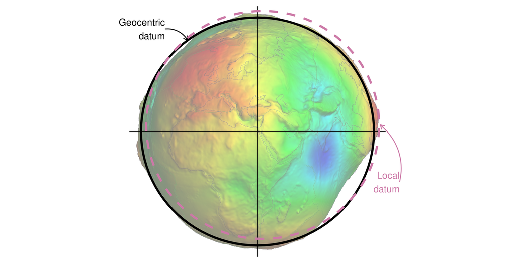

## Geographic CRS

- Normally uses a **geocentric datum**
- Uses **angular measurement units** (e.g., degrees of longitude and latitude) to locate something in space
- **Longitude**: location in the East-West direction
- **Latitude**: location in the North-South direction
- Popular example: **WGS84**

[figure not shown]

## Projected CRS

- Normally uses a **local datum**
- Convert the three-dimensional surface of the Earth into Easting and Northing (x and y)
- Uses **linear measurement units**, as for ex., **meters**
- Popular example: **Universal Transverse Mercator (UTM)**

## Projected CRS: UTM

- Divides the Earth into 60 zones, each 6° of longitude in width.
- Each zone uses a transverse Mercator projection that maps a region of large north-south extent with low distortion.
- Each partition has a numerical code followed by the N-S hemisphere

## Projected CRS: UTM

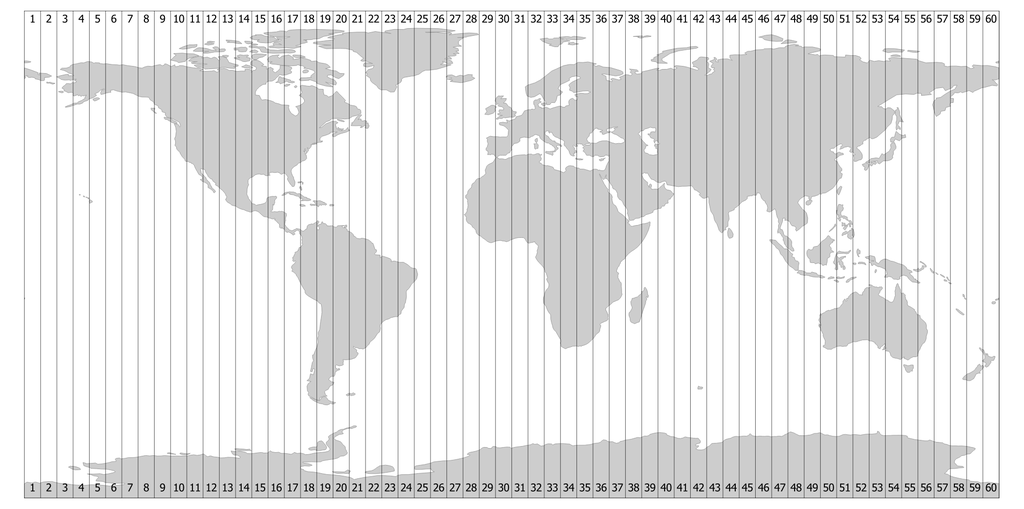

## Projected CRS: UTM in the USA

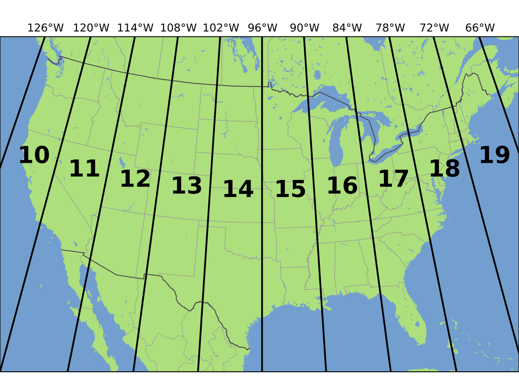

- Georgia is within zones **16 and 17 North**

## Geographic vs. Projected CRS

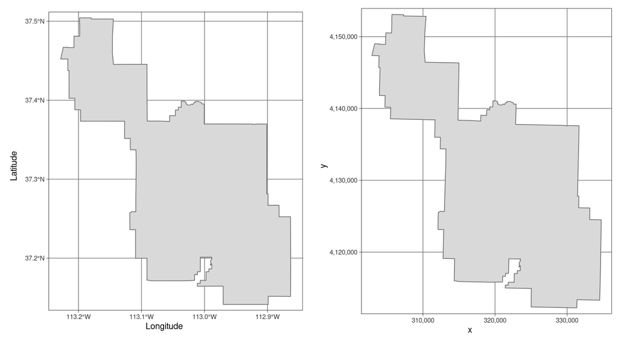

- Can you spot the difference(s)? Which is which?

## Geographic vs. Projected CRS

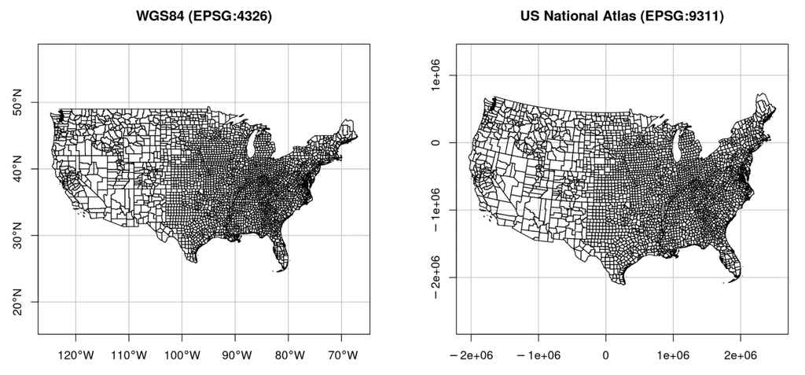

- What about now?

## How to refer to a CRS?

CRSs can be described in many ways, including:

- Simple and ambiguous statements like “it’s in lon/lat coordinates”
- Formalized yet now outdated ‘proj4 strings’ (also known as ‘proj-string’) such as +proj=longlat +ellps=WGS84 +datum=WGS84 +no_defs
- With an identifying ‘authority:code’ text string such as EPSG:4326 (**preferable**)
- With a WKT description (most thorough, though long)

## Why is EPSG preferable?

- Machine readable
- Short and easy to remember and reference to
- Easily findable online on [EPSG website](https://epsg.io/)

## Why should I care about CRS?

When working with multiple geospatial layers, it is important to have them on the same CRS so layering operations can work properly.

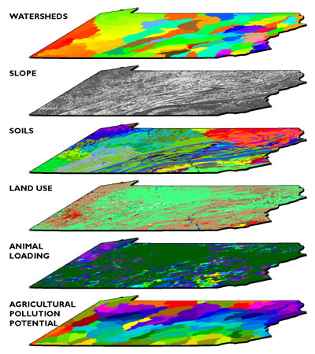

## Why should I care about geographic vs. projected CRS?

- Knowing which CRS your data is in, and whether it is in geographic (lon/lat) or projected (typically meters), is **important and has consequences** for how R handles spatial and geometry operations
- R has become better to project on-the-fly geographic CRSs for distance-based operations like buffering, clipping, etc.
- However, still not fool proof:

## Why should I care about geographic vs. projected CRS?

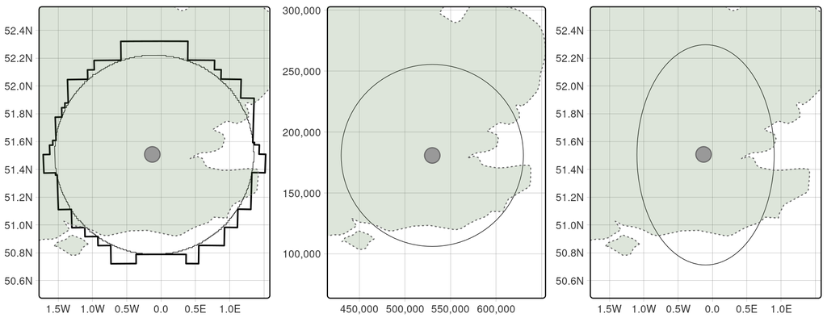

## Bottom line is…

- Need to have geospatial layers within a project containing the same CRS
- If **CRS is absent**, need to **set** the original CRS of that object
- If **CRS is present but different**, need to **transform** it to a common one
- If conducting distance-based operations, preferable to have layers in a **projected CRS**

## Recapping

- CRS sets the spatial location of an object
- Geographic vs. projected CRS
- Need to have layers in a project under same CRS
- Prefer projected CRS when performing distance-based operations

## Some common CRS and their EPSG codes for this class

- Geographic: WGS84 is [EPSG:4326](https://epsg.io/4326)
- Projected: UTM Zone 17N is [EPSG:32617](https://epsg.io/32617)